# 320 Final Project

Everyone is always big into sports, whether it’s football, basketball, baseball, etc. However, esports are something I’ve watched since I was in high school, and I still follow many esports to this day. One of the biggest esports right now is League of Legends, with an average of around 200,000 viewers across all of its global leagues. Currently the first worlds tournament of the year is going on, with teams from around the world meeting in South Korea to compete amongst each other. The big question coming into this tournament was how teams from different leagues would compete against each other. Instead of taking guesses on how each team would play, I decided to find match data from all leagues and use the numbers to compare teams within each league to each other as well as whole leagues to other leagues as a whole. The goal of this data would be to determine if teams from around the world played differently.

## Background Information

I wanted to give some very basic information on the game of League of Legends, specifically covering things that will show up in the data below. League of Legends (also can be shortened to just League) is a 5v5 MOBA, with all 10 players choosing a different character to play. The final goal of the game is to defeat the enemy’s base, but in order to accomplish that and get stronger, teams will work to get gold. Gold can be achieved through multiple ways, including towers (column towers), dragons (column dragons), player kills (column teamkills), and minion/monster kills (column total cs). In general, gold can be tracked under the column totalgold which gives the total gold by each player/team for the whole game. While gold isn’t an accurate representation of the results of games, usually the team with more gold is considered stronger. The last semi-important column for now is patch, which gives the game patch the match was played on. League of Legends is updated every two weeks, where characters that are too strong are nerfed and characters that are considered weak are buffed. Columns will be explained again as they are used throughout this project. To get an overview of the game, the developers provided a quick tutorial at https://www.leagueoflegends.com/en-us/how-to-play/

## Data Scraping

To determine how regions play, we need to find match data from all leagues. https://oracleselixir.com/tools/downloads has match data for all matches that happen every year, so we want match data specifically from this year:

```python
import requests
from bs4 import BeautifulSoup
from pprint import pprint
import pandas as pd
import datetime as dt
import numpy as np
import re
import seaborn
import matplotlib.pyplot as plt

#Grab the csv from the website
data = pd.read_csv("https://oracleselixir-downloadable-match-data.s3-us-west-2.amazonaws.com/2022_LoL_esports_match_data_from_OraclesElixir_20220515.csv")
data.head()
```

|  | gameid | datacompleteness | url | league | year | split | playoffs | date | game | patch | ... | opp_csat15 | golddiffat15 | xpdiffat15 | csdiffat15 | killsat15 | assistsat15 | deathsat15 | opp_killsat15 | opp_assistsat15 | opp_deathsat15 |
| --- | --- | --- | --- | --- | --- | --- | --- | --- | --- | --- | --- | --- | --- | --- | --- | --- | --- | --- | --- | --- | --- |
| 0 | ESPORTSTMNT01_2690210 | complete | NaN | LCK CL | 2022 | Spring | 0 | 2022-01-10 07:44:08 | 1 | 12.01 | ... | 121.0 | 391.0 | 345.0 | 14.0 | 0.0 | 1.0 | 0.0 | 0.0 | 1.0 | 0.0 |
| 1 | ESPORTSTMNT01_2690210 | complete | NaN | LCK CL | 2022 | Spring | 0 | 2022-01-10 07:44:08 | 1 | 12.01 | ... | 100.0 | 541.0 | -275.0 | -11.0 | 2.0 | 3.0 | 2.0 | 0.0 | 5.0 | 1.0 |
| 2 | ESPORTSTMNT01_2690210 | complete | NaN | LCK CL | 2022 | Spring | 0 | 2022-01-10 07:44:08 | 1 | 12.01 | ... | 119.0 | -475.0 | 153.0 | 1.0 | 0.0 | 3.0 | 0.0 | 3.0 | 3.0 | 2.0 |
| 3 | ESPORTSTMNT01_2690210 | complete | NaN | LCK CL | 2022 | Spring | 0 | 2022-01-10 07:44:08 | 1 | 12.01 | ... | 149.0 | -793.0 | -1343.0 | -34.0 | 2.0 | 1.0 | 2.0 | 3.0 | 3.0 | 0.0 |
| 4 | ESPORTSTMNT01_2690210 | complete | NaN | LCK CL | 2022 | Spring | 0 | 2022-01-10 07:44:08 | 1 | 12.01 | ... | 21.0 | 443.0 | -497.0 | 7.0 | 1.0 | 2.0 | 2.0 | 0.0 | 6.0 | 2.0 |

5 rows × 123 columns

Now that we have the match data we want to remove columns that aren’t necessary. Columns that give opponent data (i.e. opp_dragons, opp_towers, etc.) are not needed and can be removed since the opponent’s data is also in the dataset, just in a different row. We can also remove niche data like doublekills, firstbloodkill, etc. since it doesn’t provide valuable information. Finally, we remove gameid, url, and datacompleteness as they are not needed.

```python
#drop columns we don't need
data = data.drop(columns=['gameid', 'url', 'datacompleteness', 'doublekills', 'triplekills', 'quadrakills', 'pentakills', 'firstbloodkill', 'firstbloodassist', 'firstbloodvictim', 'monsterkillsownjungle', 'monsterkillsenemyjungle', 'opp_killsat15', 'opp_assistsat15', 'opp_deathsat15', 'opp_dragons', 'opp_elementaldrakes', 'chemtechs', 'dragons (type unknown)', 'opp_elders', 'opp_heralds', 'opp_barons', 'opp_towers', 'firstmidtower', 'firsttothreetowers', 'opp_turretplates', 'opp_inhibitors', 'goldat10', 'xpat10', 'csat10', 'opp_goldat10', 'opp_xpat10', 'opp_csat10', 'golddiffat10', 'xpdiffat10', 'csdiffat10', 'killsat10', 'assistsat10', 'deathsat10', 'opp_killsat10', 'opp_assistsat10', 'opp_deathsat10', 'opp_goldat15', 'opp_xpat15', 'opp_csat15', 'playerid', 'teamid', 'year', 'teamkills', 'teamdeaths', 'damagetakenperminute', 'damagemitigatedperminute', 'wpm', 'wardskilled', 'wcpm', 'vspm', 'earnedgold', 'earned gpm', 'earnedgoldshare', 'goldspent', 'cspm', 'assistsat15', 'firstbaron', 'firstherald', 'ckpm', 'elementaldrakes', 'split', 'game'])
```

Next thing we need to do is separate player and team data, since both are currently contained in the same dataset. We can do this by looking at the participantid column, since players are labeled 1-10 and teams are labeled 100 or 200.

```python
#Separate Team and Player Data

#Team Data is marked by participant id 100 or 200
teamData = data.loc[(data['participantid'] == 100) | (data['participantid'] == 200)]
#Player Data is marked by participant id 1 - 10
playerData = data.loc[(data['participantid'] != 100) & (data['participantid'] != 200)]
```

Now that we have two datasets, one for players and one for teams, we can remove columns that will only be useful to one or the other. For example, game time would only be useful for teams, and champion is only used for players. We go through each dataset and remove those unnecessary columns.

```python
#drop columns we don't need
teamData = teamData.drop(columns=['playername', 'champion', 'damageshare', 'total cs', 'position', 'participantid'])
playerData = playerData.drop(columns=['participantid', 'ban1', 'ban2', 'ban3', 'ban4', 'ban5', 'firstblood', 'team kpm', 'firstdragon', 'dragons', 'infernals', 'mountains', 'clouds', 'oceans', 'hextechs', 'elders', 'heralds', 'barons', 'firsttower', 'towers', 'turretplates', 'inhibitors', 'gspd'])
```

Now we’re ready to start our work!

## Data Visualization and Analysis

After doing a lot of deletion and separation, we have two dataframes: teamData and playerData. Each dataframe has the following information:

#### Definitions

- Position: Each player plays one of five positions: top, jng, mid, bot, sup. Each position represents a different position on the map

- CS: Score of number of minions and monsters killed. Higher the number, more minions/monsters killed

- Bans: Each team gets to ban champions that they don't want the other team playing

- XP: As you sit next to dying minions and monsters, they give xp that help players level up and get stronger

#### teamData:

- League (what region the team plays in)

- Playoffs (0 if not a playoffs game, 1 if it is)

- Date (date of game)

- Patch (what patch the game is played on)

- Side (red or blue, each team starts on a different side for the game)

- Teamname

- Ban1, Ban2, Ban3, Ban4, Ban5 (ban 1-5 for the team)

- Gamelength (length of game)

- Result (0 for loss, 1 for win)

- Kills, deaths, assists (total kills, deaths, assists for team)

- Firstblood (first blood is first kill of game) (0 if team did not get first blood, 1 if team did)

- Team kpm (team kills per minute)

- Firstdragon (first dragon killed for the game) (0 if team did not get first dragon, 1 if team did)

- Dragons (total team dragons)

- Infernals, mountains, clouds, oceans, hextechs, elders (type of dragon obtained by team)

- Heralds (number of heralds, type of monster, killed by team)

- Barons (number of barons, type of monster, killed by team)

- Firsttower (first tower killed for the game) (0 if team did not get first tower, 1 if team did)

- Towers (total towers destroyed by team)

- Turretplates (total turretplates obtained by team)

- Inhibitors (total inhibitors destroyed by team)

- Damagetochampions (total damage to champions)

- Dpm (total damage per minute)

- Wardsplaced (total wards placed by team)

- Controlwardsbought (total control wards bought)

- Visionscore (total team vision score)

- Totalgold (total team gold)

- Gspd (gold spread compared to the other team)

- Minionkills, monsterkills (team minion, monster kills)

- Goldat15, xpat15, csat15 (team gold, xp, cs at 15 minutes into the game)

- Golddiffat15, xpdiffat15, csdiffat15 (team gold, xp, cs differential compared to opponents at 15 minutes into the game)

- Killsat15, deathsat15 (team kills, deaths at 15 minutes into the game)

#### playerData

- League (what region the player plays in)

- Playoffs (0 if not a playoffs game, 1 if it is)

- Date (date of game)

- Patch (what patch the game is played on)

- Side (red or blue, each team starts on a different side for the game)

- Position (position by player)

- Playername

- Teamname

- Champion (character player played that game)

- Gamelength (length of game)

- Result (0 for loss, 1 for win)

- Kills, deaths, assists (total kills, deaths, assists for player)

- Damagetochampions (total damage to champions by player)

- Dpm (total damage per minute by player)

- Damageshare (percent of damage compared to team)

- Wardsplaced (total wards placed by player)

- Controlwardsbought (total control wards bought by player)

- Visionscore (total player vision score)

- Totalgold (total player gold)

- Totalcs (total cs, by player)

- Minionkills, monsterkills (player minion, monster kills)

- Goldat15, xpat15, csat15 (player gold, xp, cs at 15 minutes into the game)

- Golddiffat15, xpdiffat15, csdiffat15 (player gold, xp, cs differential compared to opponents at 15 minutes into the game)

- Killsat15, deathsat15 (player kills, deaths at 15 minutes into the game)

```python
teamData.head()
```

|  | league | playoffs | date | patch | side | teamname | ban1 | ban2 | ban3 | ban4 | ... | minionkills | monsterkills | goldat15 | xpat15 | csat15 | golddiffat15 | xpdiffat15 | csdiffat15 | killsat15 | deathsat15 |
| --- | --- | --- | --- | --- | --- | --- | --- | --- | --- | --- | --- | --- | --- | --- | --- | --- | --- | --- | --- | --- | --- |
| 10 | LCK CL | 0 | 2022-01-10 07:44:08 | 12.01 | Blue | Fredit BRION Challengers | Karma | Caitlyn | Syndra | Thresh | ... | 680.0 | 160.0 | 24806.0 | 28001.0 | 487.0 | 107.0 | -1617.0 | -23.0 | 5.0 | 6.0 |
| 11 | LCK CL | 0 | 2022-01-10 07:44:08 | 12.01 | Red | Nongshim RedForce Challengers | Lee Sin | Twisted Fate | Zoe | Nautilus | ... | 792.0 | 184.0 | 24699.0 | 29618.0 | 510.0 | -107.0 | 1617.0 | 23.0 | 6.0 | 5.0 |
| 22 | LCK CL | 0 | 2022-01-10 08:38:24 | 12.01 | Blue | T1 Challengers | Sona | Jarvan IV | Caitlyn | Lulu | ... | 994.0 | 215.0 | 23522.0 | 28848.0 | 533.0 | -1763.0 | -906.0 | -22.0 | 1.0 | 3.0 |
| 23 | LCK CL | 0 | 2022-01-10 08:38:24 | 12.01 | Red | Liiv SANDBOX Challengers | LeBlanc | Yuumi | Twisted Fate | Karma | ... | 1013.0 | 244.0 | 25285.0 | 29754.0 | 555.0 | 1763.0 | 906.0 | 22.0 | 3.0 | 1.0 |
| 34 | LPL | 0 | 2022-01-10 09:24:26 | 12.01 | Blue | Oh My God | Renekton | Lee Sin | Caitlyn | Jayce | ... | NaN | 172.0 | NaN | NaN | NaN | NaN | NaN | NaN | NaN | NaN |

5 rows × 49 columns

```python
playerData.head()
```

|  | league | playoffs | date | patch | side | position | playername | teamname | champion | gamelength | ... | minionkills | monsterkills | goldat15 | xpat15 | csat15 | golddiffat15 | xpdiffat15 | csdiffat15 | killsat15 | deathsat15 |
| --- | --- | --- | --- | --- | --- | --- | --- | --- | --- | --- | --- | --- | --- | --- | --- | --- | --- | --- | --- | --- | --- |
| 0 | LCK CL | 0 | 2022-01-10 07:44:08 | 12.01 | Blue | top | Soboro | Fredit BRION Challengers | Renekton | 1713 | ... | 220.0 | 11.0 | 5025.0 | 7560.0 | 135.0 | 391.0 | 345.0 | 14.0 | 0.0 | 0.0 |
| 1 | LCK CL | 0 | 2022-01-10 07:44:08 | 12.01 | Blue | jng | Raptor | Fredit BRION Challengers | Xin Zhao | 1713 | ... | 33.0 | 115.0 | 5366.0 | 5320.0 | 89.0 | 541.0 | -275.0 | -11.0 | 2.0 | 2.0 |
| 2 | LCK CL | 0 | 2022-01-10 07:44:08 | 12.01 | Blue | mid | Feisty | Fredit BRION Challengers | LeBlanc | 1713 | ... | 177.0 | 16.0 | 5118.0 | 6942.0 | 120.0 | -475.0 | 153.0 | 1.0 | 0.0 | 0.0 |
| 3 | LCK CL | 0 | 2022-01-10 07:44:08 | 12.01 | Blue | bot | Gamin | Fredit BRION Challengers | Samira | 1713 | ... | 208.0 | 18.0 | 5461.0 | 4591.0 | 115.0 | -793.0 | -1343.0 | -34.0 | 2.0 | 2.0 |
| 4 | LCK CL | 0 | 2022-01-10 07:44:08 | 12.01 | Blue | sup | Loopy | Fredit BRION Challengers | Leona | 1713 | ... | 42.0 | 0.0 | 3836.0 | 3588.0 | 28.0 | 443.0 | -497.0 | 7.0 | 1.0 | 2.0 |

5 rows × 32 columns

That’s a lot of information. Let’s look at teamData first. To make things easier we create 4 different datasets to represent the 4 different leagues we will look at: - LCKData: South Korea - LECData: Europe - LCSData: North America - LPLData: China Note: LPL as a region is missing some data (firstdragon, type of dragon, heralds, firsttower, turretplates, inhibitors, and all stats at 15 minutes into the game)

```python
#Grab data specific to the four leagues we will be looking at
LCKData = teamData.loc[(teamData['league'] == 'LCK')]
LECData = teamData.loc[(teamData['league'] == 'LEC')]
LPLData = teamData.loc[(teamData['league'] == 'LPL')]
LCSData = teamData.loc[(teamData['league'] == 'LCS')]
```

There are many ways to see how teams play differently. Some teams focus on objectives like dragons, barons, and heralds. Other teams focus on kills and damage. Let’s look at objectives first:

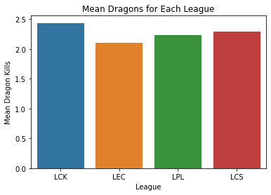

```python
#Find the mean dragon kills for each of the leagues
meanDragonKills_LCK = LCKData['dragons'].mean()
meanDragonKills_LEC = LECData['dragons'].mean()
meanDragonKills_LPL = LPLData['dragons'].mean()
meanDragonKills_LCS = LCSData['dragons'].mean()

#Create a new dataframe with each league and its mean dragon kills
dragonData = pd.DataFrame([{'league': 'LCK', 'mean': meanDragonKills_LCK}, {'league': 'LEC', 'mean': meanDragonKills_LEC}, {'league': 'LPL', 'mean': meanDragonKills_LPL}, {'league': 'LCS', 'mean': meanDragonKills_LCS}])

#Create a barplot of the mean dragon kills across the four leagues
seaborn.barplot(x='league', y='mean', data = dragonData)
plt.title('Mean Dragons for Each League')
plt.xlabel('League')
plt.ylabel('Mean Dragon Kills')
plt.show()
```

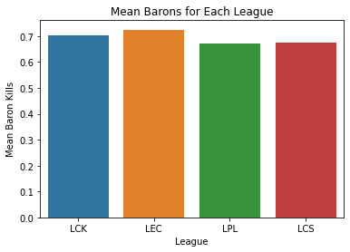

```python
#Find the mean baron kills for each league
meanBaronKills_LCK = LCKData['barons'].mean()
meanBaronKills_LEC = LECData['barons'].mean()
meanBaronKills_LPL = LPLData['barons'].mean()
meanBaronKills_LCS = LCSData['barons'].mean()

#Create a new dataframe with each league and its mean baron kills
baronData = pd.DataFrame([{'league': 'LCK', 'mean': meanBaronKills_LCK}, {'league': 'LEC', 'mean': meanBaronKills_LEC}, {'league': 'LPL', 'mean': meanBaronKills_LPL}, {'league': 'LCS', 'mean': meanBaronKills_LCS}])

#Create a barplot of the mean baron kills across the four leagues
seaborn.barplot(x='league', y='mean', data = baronData)
plt.title('Mean Barons for Each League')
plt.xlabel('League')
plt.ylabel('Mean Baron Kills')
plt.show()
```

Interesting! While the LEC usually has the least amount of dragon kills, they on average have more baron kills than the other leagues. But does this translate to wins? Right now, we’re looking at the league in general, but we don’t know if these strategies are actually winning teams games. Time to do some more data scraping!

## Dragon Kills vs. Number of Wins

We want to find the number of wins each team has in each league, so we create a copy of each of the league’s data. Since won matches are marked with a 1 under result, we can take the result column and sum them up based on team names to find the total wins for each team in the league. We then re-add this data back into our original league dataframe so we can compare it with other data.

```python
#Grab the win data for each team in the LCK
#Copy over the columns teamname and result from LCKData
LCKWinsData = LCKData[['teamname', 'result']].copy()
#Sum the result column based on teamname; this will give us total wins since under the result column 1 is a win and 0 is a loss
LCKWinsData = LCKWinsData.groupby(['teamname']).sum()
LCKWinsData
```

| teamname | result |
| --- | --- |
| DRX | 24 |
| DWG KIA | 32 |
| Fredit BRION | 21 |
| Gen.G | 32 |
| Hanwha Life Esports | 12 |
| KT Rolster | 19 |
| Kwangdong Freecs | 23 |
| Liiv SANDBOX | 11 |
| Nongshim RedForce | 16 |
| T1 | 42 |

That's important information! While it isn't necessary for what we want to accomplish, it would be useful to add total wins next to each team's game so we know if the team did well or not. Let's add that now!

```python
#Now that we have the number of wins for each team we can readd the newly acquired to the original LCKData

#Conditions based on teamname for all 10 teams in the league
conditions = [
    (LCKData['teamname'] == 'DRX'),
    (LCKData['teamname'] == 'DWG KIA'),
    (LCKData['teamname'] == 'Fredit BRION'),
    (LCKData['teamname'] == 'Gen.G'),
    (LCKData['teamname'] == 'Hanwha Life Esports'),
    (LCKData['teamname'] == 'KT Rolster'),
    (LCKData['teamname'] == 'Kwangdong Freecs'),
    (LCKData['teamname'] == 'Liiv SANDBOX'),
    (LCKData['teamname'] == 'Nongshim RedForce'),
    (LCKData['teamname'] == 'T1')
]

#Values based on total wins per team
values = LCKWinsData['result']

#Assign the total wins value based on the teamname into a new column of LCKData called totalwins
LCKData['totalwins'] = np.select(conditions, values)
LCKData
```

|  | league | playoffs | date | patch | side | teamname | ban1 | ban2 | ban3 | ban4 | ... | monsterkills | goldat15 | xpat15 | csat15 | golddiffat15 | xpdiffat15 | csdiffat15 | killsat15 | deathsat15 | totalwins |
| --- | --- | --- | --- | --- | --- | --- | --- | --- | --- | --- | --- | --- | --- | --- | --- | --- | --- | --- | --- | --- | --- |
| 1450 | LCK | 0 | 2022-01-12 06:20:03 | 12.01 | Blue | DRX | Diana | Caitlyn | Twisted Fate | LeBlanc | ... | 287.0 | 27198.0 | 30325.0 | 511.0 | 4757.0 | 1540.0 | 1.0 | 4.0 | 1.0 | 24 |
| 1451 | LCK | 0 | 2022-01-12 06:20:03 | 12.01 | Red | Liiv SANDBOX | Renekton | Lee Sin | Leona | Jayce | ... | 204.0 | 22441.0 | 28785.0 | 510.0 | -4757.0 | -1540.0 | -1.0 | 1.0 | 4.0 | 11 |
| 1462 | LCK | 0 | 2022-01-12 09:02:13 | 12.01 | Blue | DRX | Diana | Caitlyn | Yuumi | Samira | ... | 186.0 | 23612.0 | 29371.0 | 528.0 | -1045.0 | -735.0 | -18.0 | 2.0 | 4.0 | 24 |
| 1463 | LCK | 0 | 2022-01-12 09:02:13 | 12.01 | Red | Liiv SANDBOX | Renekton | Lee Sin | Twisted Fate | Viktor | ... | 227.0 | 24657.0 | 30106.0 | 546.0 | 1045.0 | 735.0 | 18.0 | 4.0 | 2.0 | 11 |
| 1486 | LCK | 0 | 2022-01-12 10:07:10 | 12.01 | Blue | T1 | Lee Sin | Ryze | Viktor | LeBlanc | ... | 236.0 | 24357.0 | 29835.0 | 518.0 | 1309.0 | -170.0 | -15.0 | 3.0 | 1.0 | 42 |
| ... | ... | ... | ... | ... | ... | ... | ... | ... | ... | ... | ... | ... | ... | ... | ... | ... | ... | ... | ... | ... | ... |
| 55907 | LCK | 1 | 2022-04-02 09:11:08 | 12.05 | Red | T1 | Zeri | Karma | Twisted Fate | Rakan | ... | 252.0 | 25516.0 | 29542.0 | 556.0 | 1878.0 | -836.0 | 28.0 | 3.0 | 3.0 | 42 |
| 55954 | LCK | 1 | 2022-04-02 10:20:21 | 12.05 | Blue | T1 | Hecarim | Ryze | Karma | Malphite | ... | 287.0 | 27934.0 | 30935.0 | 532.0 | 4660.0 | 2663.0 | 69.0 | 5.0 | 1.0 | 42 |
| 55955 | LCK | 1 | 2022-04-02 10:20:21 | 12.05 | Red | Gen.G | Zeri | Caitlyn | Twisted Fate | Nautilus | ... | 199.0 | 23274.0 | 28272.0 | 463.0 | -4660.0 | -2663.0 | -69.0 | 1.0 | 5.0 | 32 |
| 56026 | LCK | 1 | 2022-04-02 11:30:46 | 12.05 | Blue | Gen.G | Caitlyn | Jayce | Karma | Tryndamere | ... | 147.0 | 23253.0 | 28971.0 | 501.0 | -4248.0 | -2060.0 | -24.0 | 1.0 | 7.0 | 32 |
| 56027 | LCK | 1 | 2022-04-02 11:30:46 | 12.05 | Red | T1 | Zeri | Twisted Fate | Hecarim | Malphite | ... | 212.0 | 27501.0 | 31031.0 | 525.0 | 4248.0 | 2060.0 | 24.0 | 7.0 | 1.0 | 42 |

464 rows × 50 columns

Now that we have total wins we can use it to chart dragon kills and total wins to see if on average more dragon kills means more wins for a team. First we find the mean number of dragon kills for each team:

```python
#Grab the mean dragon kills for each team in the LCK
#Copy over the columns teamname and dragons from LCKData
LCKDragonData = LCKData[['teamname', 'dragons']].copy()
#Aggregate based on teamname and get the mean of dragons for each team
LCKDragonData = LCKDragonData.groupby(['teamname']).mean()
LCKDragonData
```

| teamname | dragons |
| --- | --- |
| DRX | 2.152174 |
| DWG KIA | 2.980000 |
| Fredit BRION | 2.531915 |
| Gen.G | 2.816327 |
| Hanwha Life Esports | 1.953488 |
| KT Rolster | 2.720930 |
| Kwangdong Freecs | 2.460000 |
| Liiv SANDBOX | 2.024390 |
| Nongshim RedForce | 2.088889 |
| T1 | 2.500000 |

Now we can plot the mean number of dragon kills vs. number of wins in the LCK!

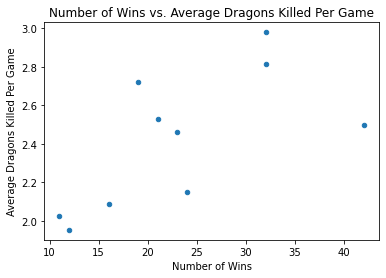

```python
#We combine the table with total wins and the table with mean dragon kills
TotalLCKData = pd.concat([LCKWinsData, LCKDragonData], axis=1, join='inner')

#We can now scatter plot the number of wins vs. mean dragon kills and compare it for all 10 teams in the league
ax = TotalLCKData.plot('result', 'dragons', kind='scatter')
plt.title('Number of Wins vs. Average Dragons Killed Per Game')
plt.xlabel('Number of Wins')
plt.ylabel('Average Dragons Killed Per Game')
plt.show()
```

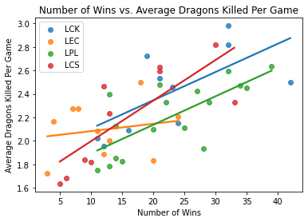

```python
#We do all the steps above for the other 3 leagues

#First line copies over teamname and result from "league"Data
#Second line groups by teamname and sums the result to find totalwins for each team in that league
#Third line copies over teamname and dragons from "League"Data
#Fourth line groups by teamname and finds the mean of dragons kills for each team in that league
#Fifth line concats the two tables together into one table

LECWinsData = LECData[['teamname', 'result']].copy()
LECWinsData = LECWinsData.groupby(['teamname']).sum()
LECDragonData = LECData[['teamname', 'dragons']].copy()
LECDragonData = LECDragonData.groupby(['teamname']).mean()
TotalLECData = pd.concat([LECWinsData, LECDragonData], axis=1, join='inner')

LPLWinsData = LPLData[['teamname', 'result']].copy()
LPLWinsData = LPLWinsData.groupby(['teamname']).sum()
LPLDragonData = LPLData[['teamname', 'dragons']].copy()
LPLDragonData = LPLDragonData.groupby(['teamname']).mean()
TotalLPLData = pd.concat([LPLWinsData, LPLDragonData], axis=1, join='inner')

LCSWinsData = LCSData[['teamname', 'result']].copy()
LCSWinsData = LCSWinsData.groupby(['teamname']).sum()
LCSDragonData = LCSData[['teamname', 'dragons']].copy()
LCSDragonData = LCSDragonData.groupby(['teamname']).mean()
TotalLCSData = pd.concat([LCSWinsData, LCSDragonData], axis=1, join='inner')

#We then create a regression plot for each league, which will scatter the datapoints and give a regression line
seaborn.regplot(x=TotalLCKData['result'], y=TotalLCKData['dragons'], ci=None, label="LCK")
seaborn.regplot(x=TotalLECData['result'], y=TotalLECData['dragons'], ci=None, label="LEC")
seaborn.regplot(x=TotalLPLData['result'], y=TotalLPLData['dragons'], ci=None, label="LPL")
seaborn.regplot(x=TotalLCSData['result'], y=TotalLCSData['dragons'], ci=None, label="LCS")

plt.title('Number of Wins vs. Average Dragons Killed Per Game')
plt.xlabel('Number of Wins')
plt.ylabel('Average Dragons Killed Per Game')
plt.legend()
plt.show()
```

In general, more dragon kills per game means more wins, however we can see that this statement means more in some leagues than in others. In the LCS, dragon kills seem to be more impactful on games than in the LEC. Something that would be interesting to see is how many dragons the LEC team goes for when competing against other teams from other regions that prioritize dragons more.

## Gold Spent Across the Leagues

Gold is very important in League of Legends. More gold means more items means more damage, which usually means the team with more gold wins. However, there are cases where teams come from behind and win with less gold than their opponents. Let’s first look at the distribution of total gold for games across the four leagues.

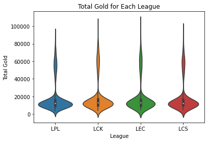

```python
#We grab the data for only teams in the four leagues we care about
totalgoldData = data.loc[(data['league'] == 'LCK') | (data['league'] == 'LEC') | (data['league'] == 'LPL') | (data['league'] == 'LCS')]

#We create a violinplot comparing each league and the total gold earned across all games
seaborn.violinplot(x='league', y='totalgold', data=totalgoldData)
plt.title('Total Gold for Each League')
plt.xlabel('League')
plt.ylabel('Total Gold')
plt.show()
```

This graph shows that on average games end with a total gold of around 10000, 15000. That doesn’t really help us, so now let’s look at gspd. GSPD, or gold spent percentage difference, is the difference between the gold each team spent divided by the average gold spent that game. More on GSPD can be learnt here https://oracleselixir.com/2015/07/measuring-the-margins-gold-spent-percentage-difference/

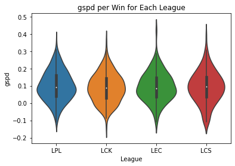

```python
#Since both the winner and loser are present in this dataset, we only take winners so games are not counted twice and offset each other
WinData = data.loc[(data['result'] == 1)]
#We grab the same data as above for the four leagues we care about
gspdData = WinData.loc[(WinData['league'] == 'LCK') | (WinData['league'] == 'LEC') | (WinData['league'] == 'LPL') | (WinData['league'] == 'LCS')]

#We create another violinplot, this time with gspd data
seaborn.violinplot(x='league', y='gspd', data=gspdData)
plt.title('gspd per Win for Each League')
plt.xlabel('League')
plt.ylabel('gspd')
plt.show()
```

## Game Length Across the Leagues

The last thing I wanted to look at for each league was average game length. Teams that finish games faster tend to have a faster early game while teams that finish games slower have a better late game. I wondered which styles each league had and whether or not these styles would clash.

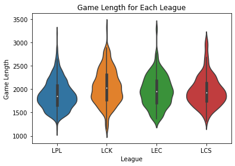

```python
#Same as above, we grab for the four leagues, using WinData so games are only counted once
gamelengthData = WinData.loc[(WinData['league'] == 'LCK') | (WinData['league'] == 'LEC') | (WinData['league'] == 'LPL') | (WinData['league'] == 'LCS')]

#We create a violinplot comparing the four leagues and their gametime
seaborn.violinplot(x='league', y='gamelength', data=gspdData)
plt.title('Game Length for Each League')
plt.xlabel('League')
plt.ylabel('Game Length')
plt.show()
```

It seems like on average the LPL has many fast games while the LCK has some of the slower games. This is interesting because these two regions are considered the best of the best, so what will happen when they compete against each other? Will the LPL team be able to finish games faster or will the LCK team be able to last it out and win late?

## Player Data

Finally let’s look at some player specific data. Usually, a player’s contribution is connected to damage done during the game, with a player doing more damage considered being more impactful. Let’s look at the average dpm of the top players in the world.

```python
#We copy over league, position, playername, and dpm from playerData
damageData = playerData[['league', 'position', 'playername', 'dpm']].copy()
#We then only grab players in one of the four leagues we care about
damageData = damageData.loc[(data['league'] == 'LCK') | (data['league'] == 'LEC') | (data['league'] == 'LPL') | (data['league'] == 'LCS')]
#We then aggregate by league, position, and playername, and finding the mean of dpm for that specific player
damageData = damageData.groupby(['league', 'position', 'playername']).mean()
#We then sort the data in descending order
damageData = damageData.sort_values(by=['dpm'], ascending=False)
```

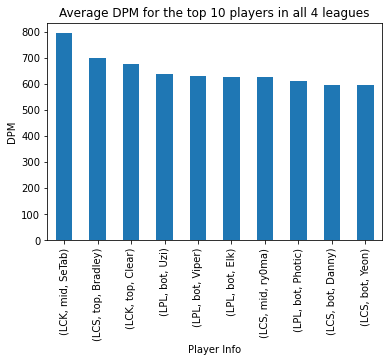

```python
#We grab the data of the first 10 players with the highest average dpm
first10dpm = damageData.head(10)
#We plot this data onto a bar plot
ax = first10dpm.plot.bar(legend=False)
plt.title('Average DPM for the top 10 players in all 4 leagues')
plt.xlabel('Player Info')
plt.ylabel('DPM')
plt.show()
```

```python
#Find playerData specific to one of the four leagues
LCKPlayerData = playerData.loc[(playerData['league'] == 'LCK')]
LECPlayerData = playerData.loc[(playerData['league'] == 'LEC')]
LPLPlayerData = playerData.loc[(playerData['league'] == 'LPL')]
LCSPlayerData = playerData.loc[(playerData['league'] == 'LCS')]

#The next lines are all similar just for different leagues
#First line copies over position, dpm from the league specific player data
#Second line aggregates the position and finds the mean of dpm for each position

LCKPositionData = LCKPlayerData[['position', 'dpm']].copy()
LCKPositionData = LCKPositionData.groupby(['position']).mean()

LECPositionData = LECPlayerData[['position', 'dpm']].copy()
LECPositionData = LECPositionData.groupby(['position']).mean()

LPLPositionData = LPLPlayerData[['position', 'dpm']].copy()
LPLPositionData = LPLPositionData.groupby(['position']).mean()

LCSPositionData = LCSPlayerData[['position', 'dpm']].copy()
LCSPositionData = LCSPositionData.groupby(['position']).mean()
```

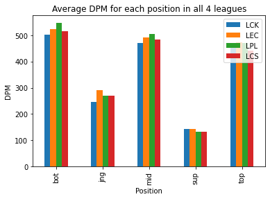

```python
#We combine data from all four leagues into one dataframe
TotalPositionData = pd.concat([LCKPositionData, LECPositionData, LPLPositionData, LCSPositionData], axis=1, join='inner')

#Then we create a barplot from the combined data
ax = TotalPositionData.plot.bar()
plt.title('Average DPM for each position in all 4 leagues')
plt.xlabel('Position')
plt.ylabel('DPM')
plt.legend(["LCK", "LEC", "LPL", "LCS"])
plt.show()
```

Sort of replicating the top 10 graph, the bot lane had the most impact in the LPL, while in the LEC, top, mid, and bot all had similar impact on the game. This shows how the different positions have different impacts in each league.

## Conclusion

After comparing the leagues amongst themselves, it’s safe to conclude that each league has a different playstyle. We saw how the LEC tends to focus less on dragons but more on barons. We saw how the LPL prefers shorter games and the LCK prefers longer ones. We also got data that covers all the leagues as a whole. We saw how in general the more dragons you kill the more wins you would have. We also saw the impact each position had on their league.

Some further research can be done on other smaller regions like Vietnam, Turkey, Latan America, etc. There is also match data on the international tournament that is currently happening, and while the tournament isn't complete, these matches can eventually help show if teams continue the same trends from their own leauges or if they adapt to their opponent's strategy. Because League has so many aspects to their game and things are constantly changing patch to patch, there are many more datapoints that can be looked at in the future.